# Dhruv Aggarwal

Email [LinkedIn](https://www.linkedin.com/in/dhruvaggarwal028) [ORCID](https://orcid.org/0000-0002-1999-6878) [OSF](https://osf.io/e3t7j/) [GitHub](https://github.com/DhruvAggarwal2002) CV

## About

I am an experimental neuroscientist specializing in cognitive neuroscience and empirical memory research. I hold an MSc (Distinction) in Brain Sciences from the University of Glasgow. I am experienced in programming and executing controlled multifactorial cognitive experiments and eye-tracking paradigms. My research interests focus on mapping the neural bases for memory processes in the human brain. I am also an active advocate of open science practices such as preregistrations, preprints, and data sharing.

## Education

**MSc Brain Sciences** | University of Glasgow, United Kingdom | 2024-2025

*Grade*: Distinction  
*Thesis*: “Associative Asymmetry in Episodic Memory: An Experimental Study on Directional Biases in Recall Using Picture Sequences”

**BA (Hons.) Psychology** | O. P. Jindal Global University, India | 2021-2024

*Grade*: CGPA 8.0/8.0 | Gold Medal - 1st position in cohort  
*Thesis*: “Internet Browsing Behaviour and its Influence on Cognitive Processing in College Students: A Study Among Indian Young Adults”

## Research Experience

**Research Intern** | O. P. Jindal Global University, India

Remote | 05/2026 - Present

- *Supervisor*: Dr. Kanika Malik | Funding: Wellcome Trust & King’s College London
- *Project*: ‘METROPOLIS (Mechanistic Trial of Problem Solving and Behavioural Activation for Depression)’
- Engaging in psychometric assessment, statistical analysis and data visualization from the testing phase of the project.

**Research Assistant** | Emotion and Cognition Research Centre, JSPC, India

Hybrid | 06/2024 - 06/2026

- *Supervisor*: Dr. Divya Bhatia | Funding: O. P. Jindal Global University
- *Project*: ‘Personal Memory in the Digital Age: Scoping Review of Social Media Posting Effects’
- Led a scoping review following PRISMA-SCR guidelines; developed Boolean search strings, led dual-stage screening and data extraction across Scopus and PubMed.

## Teaching & Mentorship

**Director of Research Initiatives** | Tertiary Education Advisors (TEA)

Remote | 01/2026 - Present

- Involved in the development of the Trishul Research Program initiative - a collaborative research mentorship opportunity for high school and undergraduate students.
- Responsible for auditing the program’s governing academic policy and compliance with international research standards while also coordinating with a multidisciplinary and international cohort of academic mentors.
- Offering one-to-one mentorship for high school and undergraduate students in research design, academic writing, and manuscript development within psychology and neuroscience.

## Open Science

**Reviewer for Open Science Curriculum** | Framework for Open and Reproducible Research Training (FORRT)

Remote | 09/2025 - Present

- Contributed to international initiatives promoting transparent and reproducible research practices.
- Reviewed educational materials promoting open science, pre-registration, and reproducibility in research.

## Peer Review

I have peer reviewed for the Journal of Open Psychology Data and am open to more reviewing opportunities.

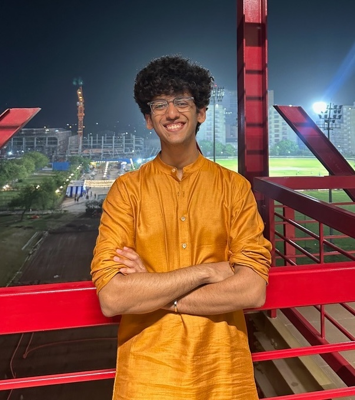